# project

Danilo Canivel(canivel2)

7/31/2019

```r
library(lubridate)
```

```r
library(ggplot2)
library(cluster)
library(tidyverse)
library(caret)
library(magrittr)
library(Matrix)
library(faraway)
```

## Read Data

** We are using a small chunk of the data just to be able to run some local hipotheses**

```r
nrows = 100000
fdata = read.csv("./input/train.csv", stringsAsFactors=FALSE, nrows=nrows)
```

## Feature Engineering

** Several features are been created on this step: ** - First if we are processing for training, we are gonna remove several outliers relate to fare amount, location and passenger count - Next we fatorize some of the features to work as categories - time for example is factorize in 6 different categories - the locations are converted in radius - We decided to add a few locations where taxis usually take or drop passengers in NYC. - We Compute haversine distance and Bearing distances - https://en.wikipedia.org/wiki/Haversine_formula - https://en.wikipedia.org/wiki/Bearing_(navigation)

```r
earth_radius = 6371 #in kms

sphere_dist = function(pickup_lat, pickup_lon, dropoff_lat, dropoff_lon)
{
    #Compute distances along lat, lon dimensions
    dlat = dropoff_lat - pickup_lat
    dlon = dropoff_lon - pickup_lon

    #Compute  distance
    a = sin(dlat/2.0)**2 + cos(pickup_lat) * cos(dropoff_lat) * sin(dlon/2.0)**2

    return (2 * earth_radius * asin(sqrt(a)))

}

features_eng = function(data, istrain=TRUE){

  if(istrain == TRUE){
    data = data[complete.cases(data),]
    # Remove Negative Fare and No Passenger and some places that does not exist
    data = data[(data$fare_amount > 0 & data$fare_amount <= 500),]
    data = data[(data$pickup_longitude > -80 && data$pickup_longitude < -70),]
    data = data[(data$pickup_latitude > 35 && data$pickup_latitude < 45),]
    data = data[(data$dropoff_longitude > -80 && data$dropoff_longitude < -70),]
    data = data[(data$dropoff_latitude > 35 && data$dropoff_latitude < 45),]
    #only if passengers are between 1 and 9
    data = data[(data$passenger_count > 0 && data$passenger_count < 10),]
  }

  # Convert to datetime obj
  data$pickup_datetime = as_datetime(data$pickup_datetime, tz="UTC")

  # factorization
  data$year = as.factor(year(data$pickup_datetime))
  data$month = as.factor(month(data$pickup_datetime))
  data$day = as.factor(day(data$pickup_datetime))
  data$weekday = as.factor(weekdays(data$pickup_datetime))

  #factor time of the day
  hour = hour(data$pickup_datetime)
  data$time = as.factor(ifelse(hour < 7, "Overnight",
                               ifelse(hour < 11, "Morning",
                                      ifelse(hour < 16, "Noon",
                                             ifelse(hour < 20, "Evening",
                                                    ifelse(hour < 23, "night", "overnight")
                        )))))
  # convert to radius position
  data$pickup_latitude = (data$pickup_latitude * pi)/180
  data$dropoff_latitude = (data$dropoff_latitude * pi)/180
  data$dropoff_longitude = (data$dropoff_longitude * pi)/180
  data$pickup_longitude = (data$pickup_longitude * pi)/180
  data$dropoff_longitude = ifelse(is.na(data$dropoff_longitude) == TRUE, 0,data$dropoff_longitude)
  data$pickup_longitude = ifelse(is.na(data$pickup_longitude) == TRUE, 0,data$pickup_longitude)
  data$pickup_latitude = ifelse(is.na(data$pickup_latitude) == TRUE, 0,data$pickup_latitude)
  data$dropoff_latitude = ifelse(is.na(data$dropoff_latitude) == TRUE, 0,data$dropoff_latitude)

  # compare locations
  data$dlat = data$dropoff_latitude - data$pickup_latitude
  data$dlon = data$dropoff_longitude - data$pickup_longitude

  #Compute haversine distance

  data$hav = sin(data$dlat/2.0)**2 + cos(data$pickup_latitude) * cos(data$dropoff_latitude) * sin(data$dlon/2.0)**2
  data$haversine = round(x = 2 * earth_radius * asin(sqrt(data$hav)), digits = 4)
  print(dim(data))

  #Compute Bearing distance
  data$dlon = data$pickup_longitude - data$dropoff_longitude
  data$bearing = atan2(sin(data$dlon * cos(data$dropoff_latitude)), cos(data$pickup_latitude) * sin(data$dropoff_latitude) - sin(data$pickup_latitude) * cos(data$dropoff_latitude) * cos(data$dlon))

  #Some point of interest where people most use taxis in NYC
  jfk_coord_lat = (40.639722 * pi)/180
  jfk_coord_long = (-73.778889 * pi)/180
  ewr_coord_lat = (40.6925 * pi)/180
  ewr_coord_long = (-74.168611 * pi)/180
  lga_coord_lat = (40.77725 * pi)/180
  lga_coord_long = (-73.872611 * pi)/180
  liberty_statue_lat = (40.6892 * pi)/180
  liberty_statue_long = (-74.0445 * pi)/180
  nyc_lat = (40.7141667 * pi)/180
  nyc_long = (-74.0063889 * pi)/180

  #calculate distances radius for the POI
  data$JFK_dist = sphere_dist(data$pickup_latitude, data$pickup_longitude, jfk_coord_lat, jfk_coord_long) + sphere_dist(jfk_coord_lat, jfk_coord_long, data$dropoff_latitude, data$dropoff_longitude)
  data$EWR_dist = sphere_dist(data$pickup_latitude, data$pickup_longitude, ewr_coord_lat, ewr_coord_long) +  sphere_dist(ewr_coord_lat, ewr_coord_long, data$dropoff_latitude, data$dropoff_longitude)
  data$lga_dist = sphere_dist(data$pickup_latitude, data$pickup_longitude, lga_coord_lat, lga_coord_long) + sphere_dist(lga_coord_lat, lga_coord_long, data$dropoff_latitude, data$dropoff_longitude)
  data$sol_dist = sphere_dist(data$pickup_latitude, data$pickup_longitude, liberty_statue_lat, liberty_statue_long) + sphere_dist(liberty_statue_lat, liberty_statue_long, data$dropoff_latitude, data$dropoff_longitude)
  data$nyc_dist = sphere_dist(data$pickup_latitude, data$pickup_longitude, nyc_lat, nyc_long) + sphere_dist(nyc_lat, nyc_long, data$dropoff_latitude, data$dropoff_longitude)

  #remove some columns
  drops <- c("key","pickup_datetime")
  data = data[, !(names(data) %in% drops)]
  print(dim(data))
  return (data)

}
```

```r
fdata = features_eng(data = fdata)
```

```
## [1] 99988    17
## [1] 99988    21
```

## Checking for outliers

** Several outliers are still present **

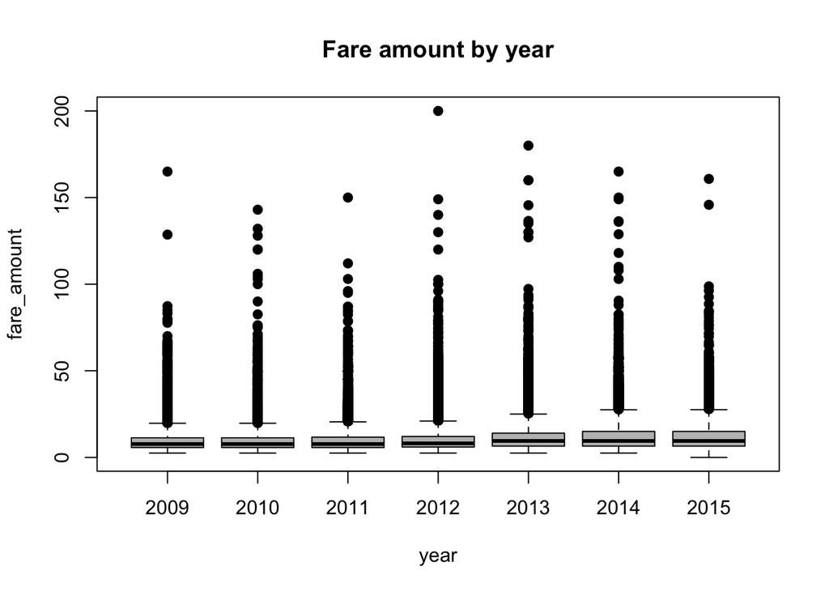

```r
fit_fy = lm(fare_amount ~ year, data = fdata)
plot(fare_amount ~ year, data = fdata, col = "grey", pch = 20, cex = 1.5,
     main = "Fare amount by year")
```

### Outlier Pickup locations

** Here we are removing the outliers from the locations based on 1.5 * IQR **

```r
fdata = fdata[fdata$pickup_longitude < median(fdata$pickup_longitude) + 1.5 * IQR( fdata$pickup_longitude) &
              fdata$pickup_longitude > median(fdata$pickup_longitude - 1.5 * IQR(fdata$pickup_longitude)) &
              fdata$pickup_latitude < median(fdata$pickup_latitude) + 1.5 * IQR(fdata$pickup_latitude) &
              fdata$pickup_latitude > median(fdata$pickup_latitude) - 1.5 * IQR(fdata$pickup_latitude),]
  print(dim(fdata))
```

```
## [1] 89089    21
```

```r
  # Outlier Dropoff locations
  fdata = fdata[fdata$dropoff_longitude < median(fdata$dropoff_longitude) + 1.5 * IQR(fdata$dropoff_longitude) &
              fdata$dropoff_longitude > median(fdata$dropoff_longitude - 1.5 * IQR(fdata$dropoff_longitude)) &
              fdata$dropoff_latitude < median(fdata$dropoff_latitude) + 1.5 * IQR(fdata$dropoff_latitude) &
              fdata$dropoff_latitude > median(fdata$dropoff_latitude) - 1.5 * IQR(fdata$dropoff_latitude),]
  print(dim(fdata))
```

```
## [1] 79043    21
```

```r
  # Outlier Fare Amount
fdata = fdata[fdata$fare_amount < median(fdata$fare_amount) + 1.5 * IQR(fdata$fare_amount),]
```

## Looks like the outliers are pretty much handle

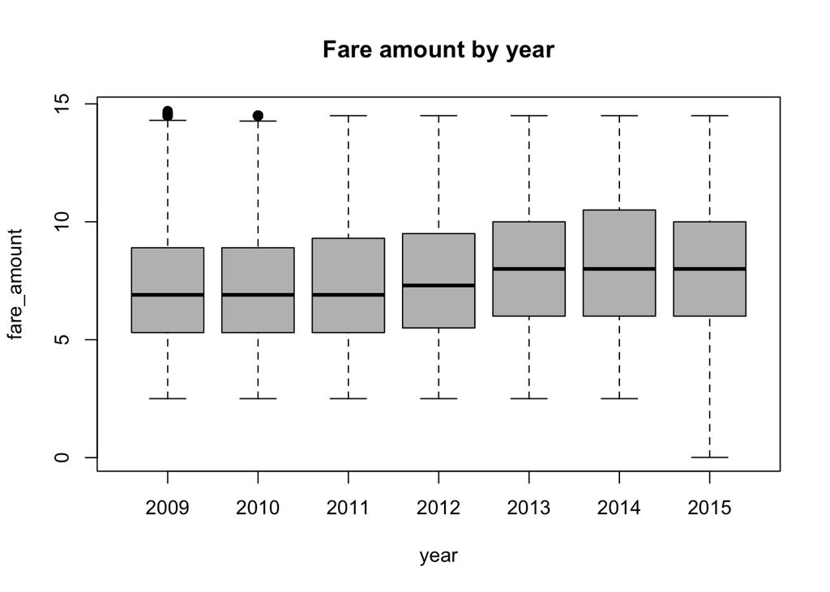

```r
fit_fy = lm(fare_amount ~ year, data = fdata)
plot(fare_amount ~ year, data = fdata, col = "grey", pch = 20, cex = 1.5,
     main = "Fare amount by year")
```

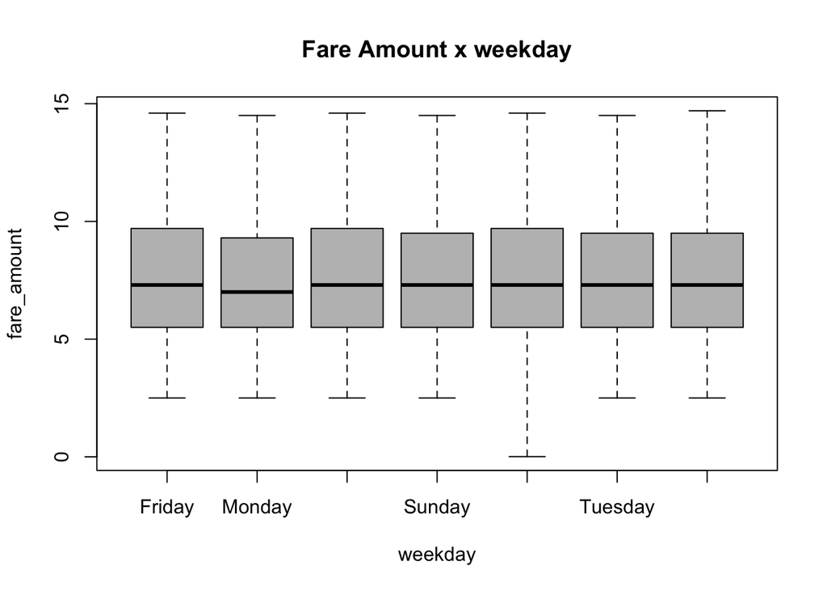

```r
plot(fare_amount ~ weekday, data = fdata,
     main   = "Fare Amount x weekday",
     col = "grey", pch = 20, cex = 1.5)
```

## Lets split the data for training and test

```r
inds = sample.int(nrow(fdata), size=nrow(fdata) * 0.9)
train = fdata[inds,]
test = fdata[-inds,]
dim(train)
```

```
## [1] 64998    21
```

```r
dim(test)
```

```
## [1] 7223   21
```

```r
head(train)
```

```
##       fare_amount pickup_longitude pickup_latitude dropoff_longitude
## 19389        13.0        -1.291378       0.7113237         -1.290849
## 54059         6.0        -1.291321       0.7107061         -1.291547
## 20840         8.1        -1.291053       0.7113153         -1.291248
## 35831         5.7        -1.291541       0.7106654         -1.291319
## 41212         6.5        -1.291219       0.7115265         -1.290907
## 8507         11.3        -1.291289       0.7110204         -1.291573
##       dropoff_latitude passenger_count year month day weekday      time
## 19389        0.7114470               3 2015     3  22  Sunday   Evening
## 54059        0.7107072               1 2013     3   8  Friday Overnight
## 20840        0.7110916               1 2010    10  24  Sunday      Noon
## 35831        0.7107397               1 2011    12  20 Tuesday      Noon
## 41212        0.7115540               5 2009     6  23 Tuesday      Noon
## 8507         0.7104844               1 2010     5  23  Sunday     night
##                dlat          dlon          hav haversine   bearing
## 19389  1.233044e-04 -0.0005291701 4.396600e-08    2.6718 -1.272184
## 54059  1.117011e-06  0.0002258805 7.327251e-09    1.0907  1.564198
## 20840 -2.237512e-04  0.0001954769 1.799872e-08    1.7095  2.556871
## 35831  7.435103e-05 -0.0002216219 8.435337e-09    1.1703 -1.153999
## 41212  2.743658e-05 -0.0003119427 1.414194e-08    1.5153 -1.455080
## 8507  -5.359906e-04  0.0002840349 8.340590e-08    3.6799  2.759602
##       JFK_dist EWR_dist lga_dist sol_dist  nyc_dist
## 19389 42.54474 35.81069 17.75318 19.54472 11.498211
## 54059 40.44173 30.13588 23.99895 11.05528  2.638054
## 20840 41.40464 34.58894 18.77995 17.44269  9.142839
## 35831 40.39406 30.15991 23.99003 11.03221  2.566172
## 41212 43.39874 37.10369 16.93680 21.39483 13.379170
## 8507  40.84264 30.43608 23.77558 11.55968  4.043397
```

## seeting the RMSE and LOORMSE functions

```r
calc_rmse = function(model) {
  sqrt(mean((resid(model) / (1 - hatvalues(model))) ^ 2))
}

calc_rmse2 = function(model, data){
  sqrt(sum((data$fare_amount - predict(model, newdata=data))^2) / nrow(data))
}
```

## Multiple Linear Regression

** Let start by doing a simple baseline model and check the results **

```r
m_additive = lm(fare_amount ~ dropoff_longitude + dropoff_latitude + pickup_latitude + pickup_longitude + passenger_count + day + weekday + time + dlat + dlon + haversine + bearing, train)
```

```r
vif(m_additive)
```

```
## dropoff_longitude  dropoff_latitude   pickup_latitude  pickup_longitude
##      2.947485e+00      2.297880e+00      2.461995e+00      3.151709e+00
##   passenger_count              day2              day3              day4
##      1.004409e+00      2.026987e+00      2.015148e+00      2.006405e+00
##              day5              day6              day7              day8
##      2.007446e+00      2.038683e+00      2.068998e+00      2.102697e+00
##              day9             day10             day11             day12
##      2.056757e+00      2.042779e+00      2.030441e+00      2.075436e+00
##             day13             day14             day15             day16
##      2.079568e+00      2.106098e+00      2.053981e+00      2.066790e+00
##             day17             day18             day19             day20
##      2.087151e+00      2.051542e+00      2.065069e+00      2.037520e+00
##             day21             day22             day23             day24
##      2.054301e+00      2.057426e+00      2.027099e+00      2.030570e+00
##             day25             day26             day27             day28
##      1.983241e+00      1.968810e+00      1.949773e+00      2.001839e+00
##             day29             day30             day31     weekdayMonday
##      1.944006e+00      1.943989e+00      1.571525e+00      1.628918e+00
##   weekdaySaturday     weekdaySunday   weekdayThursday    weekdayTuesday
##      1.716445e+00      1.626633e+00      1.695321e+00      1.669768e+00
##  weekdayWednesday       timeMorning         timenight          timeNoon
##      1.694835e+00      1.504548e+00      1.495971e+00      1.608444e+00
##     timeovernight     timeOvernight              dlat              dlon
##      1.164634e+00      1.442732e+00      6.769951e-08      4.490362e-08
##         haversine           bearing
##      6.164164e+07      6.455241e+07
```

**Both RMSE and LOORMSE are close giving a difference between 1.75 and 1.76 dolars**

```r
calc_rmse(m_additive)
```

```
## [1] 1.754307
```

```r
calc_rmse2(m_additive, test)
```

```
## [1] 1.747262
```

** Let’s try to find better features from the additive model to try to get better results **

```r
n = length(resid(m_additive))
m_add_mod_back_bic = step(m_additive, direction = "both", k = log(n))
```

```
## Start:  AIC=73510.94
## fare_amount ~ dropoff_longitude + dropoff_latitude + pickup_latitude +
##     pickup_longitude + passenger_count + day + weekday + time +
##     dlat + dlon + haversine + bearing
##
##
## Step:  AIC=73510.94
## fare_amount ~ dropoff_longitude + dropoff_latitude + pickup_latitude +
##     pickup_longitude + passenger_count + day + weekday + time +
##     dlat + haversine + bearing
##
##
## Step:  AIC=73510.94
## fare_amount ~ dropoff_longitude + dropoff_latitude + pickup_latitude +
##     pickup_longitude + passenger_count + day + weekday + time +
##     haversine + bearing
##
##                     Df Sum of Sq    RSS    AIC
## - day               30       232 199963  73254
## <none>                           199732  73511
## - pickup_latitude    1       134 199865  73543
## - passenger_count    1       158 199890  73551
## - pickup_longitude   1       714 200445  73732
## - dropoff_latitude   1       727 200458  73736
## - weekday            6      1248 200979  73849
## - dropoff_longitude  1      1430 201161  73963
## - bearing            1      3359 203090  74584
## - time               5      6102 205833  75411
## - haversine          1    294209 493940 132352
##
## Step:  AIC=73253.9
## fare_amount ~ dropoff_longitude + dropoff_latitude + pickup_latitude +
##     pickup_longitude + passenger_count + weekday + time + haversine +
##     bearing
##
##                     Df Sum of Sq    RSS    AIC
## <none>                           199963  73254
## - pickup_latitude    1       133 200096  73286
## - passenger_count    1       157 200121  73294
## - pickup_longitude   1       716 200679  73475
## - dropoff_latitude   1       729 200693  73479
## + day               30       232 199732  73511
## - weekday            6      1249 201213  73592
## - dropoff_longitude  1      1432 201395  73706
## - bearing            1      3354 203318  74324
## - time               5      6086 206049  75147
## - haversine          1    294334 494297 132066
```

```r
m_additive2 = lm(fare_amount ~ dropoff_longitude + dropoff_latitude + pickup_latitude +
    pickup_longitude + passenger_count + weekday + time + haversine +
    bearing, train)
```

** correlation still under control**

```r
vif(m_additive2)
```

```
## dropoff_longitude  dropoff_latitude   pickup_latitude  pickup_longitude
##          2.946218          2.296806          2.460449          3.150282
##   passenger_count     weekdayMonday   weekdaySaturday     weekdaySunday
##          1.003691          1.626572          1.711706          1.624442
##   weekdayThursday    weekdayTuesday  weekdayWednesday       timeMorning
##          1.690098          1.666630          1.692505          1.503643
##         timenight          timeNoon     timeovernight     timeOvernight
##          1.495082          1.607563          1.164214          1.441870
##         haversine           bearing
##          1.075168          1.991412
```

** the model perform a little better but not much to be considered**

```r
calc_rmse(m_additive2)
```

```
## [1] 1.754516
```

```r
calc_rmse2(m_additive2, test)
```

```
## [1] 1.74678
```

** lets check the statistics and the p-value for both additive models**

```r
summary(m_additive)
```

```
##
## Call:
## lm(formula = fare_amount ~ dropoff_longitude + dropoff_latitude +
##     pickup_latitude + pickup_longitude + passenger_count + day +
##     weekday + time + dlat + dlon + haversine + bearing, data = train)
##
## Residuals:
##      Min       1Q   Median       3Q      Max
## -18.7567  -1.1671  -0.3140   0.8651  11.3395
##
## Coefficients: (2 not defined because of singularities)
##                     Estimate Std. Error t value Pr(>|t|)
## (Intercept)       -1.283e+02  7.244e+01  -1.771 0.076500 .
## dropoff_longitude -9.445e+02  4.381e+01 -21.561  < 2e-16 ***
## dropoff_latitude  -4.704e+02  3.060e+01 -15.373  < 2e-16 ***
## pickup_latitude    2.116e+02  3.208e+01   6.596 4.26e-11 ***
## pickup_longitude   6.992e+02  4.590e+01  15.233  < 2e-16 ***
## passenger_count    3.829e-02  5.342e-03   7.169 7.65e-13 ***
## day2               3.451e-02  5.513e-02   0.626 0.531286
## day3               3.071e-02  5.530e-02   0.555 0.578609
## day4               4.971e-02  5.541e-02   0.897 0.369665
## day5               8.730e-02  5.541e-02   1.576 0.115138
## day6               6.620e-03  5.498e-02   0.120 0.904164
## day7               1.594e-01  5.459e-02   2.919 0.003513 **
## day8               4.567e-02  5.418e-02   0.843 0.399223
## day9               6.779e-02  5.474e-02   1.238 0.215564
## day10              8.360e-02  5.493e-02   1.522 0.128059
## day11              1.357e-01  5.509e-02   2.464 0.013753 *
## day12              1.945e-01  5.451e-02   3.569 0.000359 ***
## day13              1.258e-01  5.446e-02   2.310 0.020874 *
## day14              1.872e-01  5.414e-02   3.457 0.000546 ***
## day15              1.229e-01  5.478e-02   2.244 0.024819 *
## day16              6.065e-02  5.462e-02   1.110 0.266851
## day17              1.623e-01  5.437e-02   2.985 0.002840 **
## day18              8.154e-02  5.482e-02   1.487 0.136907
## day19              1.282e-01  5.465e-02   2.346 0.018959 *
## day20              1.269e-01  5.500e-02   2.307 0.021035 *
## day21              5.291e-02  5.478e-02   0.966 0.334157
## day22              4.247e-02  5.474e-02   0.776 0.437866
## day23              1.147e-01  5.513e-02   2.080 0.037514 *
```

[output cut: 14 more lines]

```
## timeMorning       -5.697e-02  2.192e-02  -2.599 0.009342 **
## timenight         -3.630e-01  2.224e-02 -16.324  < 2e-16 ***
## timeNoon           2.254e-01  2.014e-02  11.189  < 2e-16 ***
## timeovernight     -5.011e-01  3.542e-02 -14.147  < 2e-16 ***
## timeOvernight     -7.301e-01  2.452e-02 -29.775  < 2e-16 ***
## dlat                      NA         NA      NA       NA
## dlon                      NA         NA      NA       NA
## haversine          1.790e+00  5.787e-03 309.308  < 2e-16 ***
## bearing           -1.777e-01  5.376e-03 -33.049  < 2e-16 ***
## ---
## Signif. codes:  0 '***' 0.001 '**' 0.01 '*' 0.05 '.' 0.1 ' ' 1
##
## Residual standard error: 1.754 on 64949 degrees of freedom
## Multiple R-squared:  0.6012, Adjusted R-squared:  0.6009
## F-statistic:  2040 on 48 and 64949 DF,  p-value: < 2.2e-16
```

```r
summary(m_additive2)
```

```
##
## Call:
## lm(formula = fare_amount ~ dropoff_longitude + dropoff_latitude +
##     pickup_latitude + pickup_longitude + passenger_count + weekday +
##     time + haversine + bearing, data = train)
##
## Residuals:
##      Min       1Q   Median       3Q      Max
## -18.6747  -1.1669  -0.3174   0.8673  11.2452
##
## Coefficients:
##                     Estimate Std. Error t value Pr(>|t|)
## (Intercept)       -1.268e+02  7.245e+01  -1.750   0.0801 .
## dropoff_longitude -9.450e+02  4.381e+01 -21.569  < 2e-16 ***
## dropoff_latitude  -4.711e+02  3.060e+01 -15.393  < 2e-16 ***
## pickup_latitude    2.108e+02  3.208e+01   6.571 5.03e-11 ***
## pickup_longitude   7.000e+02  4.591e+01  15.248  < 2e-16 ***
## passenger_count    3.817e-02  5.341e-03   7.146 9.04e-13 ***
## weekdayMonday     -2.925e-01  2.602e-02 -11.245  < 2e-16 ***
## weekdaySaturday   -1.835e-01  2.503e-02  -7.334 2.27e-13 ***
## weekdaySunday     -3.690e-01  2.643e-02 -13.963  < 2e-16 ***
## weekdayThursday   -1.193e-03  2.515e-02  -0.047   0.9622
## weekdayTuesday    -5.802e-02  2.549e-02  -2.276   0.0229 *
## weekdayWednesday   7.873e-03  2.513e-02   0.313   0.7541
## timeMorning       -5.569e-02  2.192e-02  -2.541   0.0111 *
## timenight         -3.616e-01  2.224e-02 -16.260  < 2e-16 ***
## timeNoon           2.255e-01  2.014e-02  11.193  < 2e-16 ***
## timeovernight     -4.984e-01  3.543e-02 -14.067  < 2e-16 ***
## timeOvernight     -7.290e-01  2.452e-02 -29.731  < 2e-16 ***
## haversine          1.790e+00  5.788e-03 309.265  < 2e-16 ***
## bearing           -1.775e-01  5.377e-03 -33.016  < 2e-16 ***
## ---
## Signif. codes:  0 '***' 0.001 '**' 0.01 '*' 0.05 '.' 0.1 ' ' 1
##
## Residual standard error: 1.754 on 64979 degrees of freedom
## Multiple R-squared:  0.6007, Adjusted R-squared:  0.6006
## F-statistic:  5432 on 18 and 64979 DF,  p-value: < 2.2e-16
```

```r
anova(m_additive2, m_additive)
```

```
## Analysis of Variance Table
##
## Model 1: fare_amount ~ dropoff_longitude + dropoff_latitude + pickup_latitude +
##     pickup_longitude + passenger_count + weekday + time + haversine +
##     bearing
## Model 2: fare_amount ~ dropoff_longitude + dropoff_latitude + pickup_latitude +
##     pickup_longitude + passenger_count + day + weekday + time +
##     dlat + dlon + haversine + bearing
##   Res.Df    RSS Df Sum of Sq      F   Pr(>F)
## 1  64979 199963
## 2  64949 199732 30    231.89 2.5136 8.92e-06 ***
## ---
## Signif. codes:  0 '***' 0.001 '**' 0.01 '*' 0.05 '.' 0.1 ' ' 1
```

## Second model with interations

```r
m_int = lm(fare_amount ~ .^2, train)
```

** we clear see that the results are better, but probably there is some overfit since we are interatcting all the features**

** the RMSE and LOORMSE are clear better lowering the amount of errors in dollars by 1.48 - 1.50 **

```r
calc_rmse(m_int)
```

```
## [1] 1.487973
```

```r
calc_rmse2(m_int, test)
```

```
## [1] 1.490728
```

```r
anova(m_additive2, m_int)
```

```
## Analysis of Variance Table
##
## Model 1: fare_amount ~ dropoff_longitude + dropoff_latitude + pickup_latitude +
##     pickup_longitude + passenger_count + weekday + time + haversine +
##     bearing
## Model 2: fare_amount ~ (pickup_longitude + pickup_latitude + dropoff_longitude +
##     dropoff_latitude + passenger_count + year + month + day +
##     weekday + time + dlat + dlon + hav + haversine + bearing +
##     JFK_dist + EWR_dist + lga_dist + sol_dist + nyc_dist)^2
##   Res.Df    RSS   Df Sum of Sq      F    Pr(>F)
## 1  64979 199963
## 2  62989 134335 1990     65629 15.464 < 2.2e-16 ***
## ---
## Signif. codes:  0 '***' 0.001 '**' 0.01 '*' 0.05 '.' 0.1 ' ' 1
```

** comparing both the aditive and the interactive, the interactive is much better so we assume it as the better model **

```r
summary(m_int)
```

```
##
## Call:
## lm(formula = fare_amount ~ .^2, data = train)
##
## Residuals:
##      Min       1Q   Median       3Q      Max
## -11.9941  -0.8834  -0.1856   0.6572  10.7354
##
## Coefficients: (163 not defined because of singularities)
##                                      Estimate Std. Error t value Pr(>|t|)
## (Intercept)                         4.952e+06  5.931e+05   8.348  < 2e-16
## pickup_longitude                   -3.036e+07  1.340e+07  -2.265 0.023487
## pickup_latitude                     3.890e+07  8.780e+06   4.431 9.40e-06
## dropoff_longitude                   3.243e+07  1.339e+07   2.422 0.015418
## dropoff_latitude                   -4.211e+07  8.778e+06  -4.797 1.61e-06
## passenger_count                     1.111e+03  1.556e+03   0.714 0.475169
## year2010                           -6.304e+03  7.067e+03  -0.892 0.372320
## year2011                           -9.806e+03  7.073e+03  -1.386 0.165632
## year2012                           -1.193e+04  6.971e+03  -1.711 0.087001
## year2013                           -1.560e+04  7.291e+03  -2.139 0.032413
## year2014                           -2.975e+04  7.304e+03  -4.073 4.65e-05
## year2015                           -1.904e+04  9.485e+03  -2.008 0.044692
## month2                             -4.604e+03  9.418e+03  -0.489 0.624941
## month3                             -3.698e+03  9.328e+03  -0.396 0.691809
## month4                             -2.247e+04  9.241e+03  -2.432 0.015025
## month5                             -1.230e+04  9.511e+03  -1.294 0.195783
## month6                             -1.612e+04  9.206e+03  -1.751 0.079935
## month7                             -8.566e+03  9.708e+03  -0.882 0.377590
## month8                             -8.025e+03  1.008e+04  -0.796 0.425988
## month9                             -2.904e+04  9.817e+03  -2.958 0.003093
## month10                            -1.092e+04  9.739e+03  -1.122 0.261995
## month11                            -3.546e+04  1.000e+04  -3.545 0.000392
## month12                            -4.010e+04  9.843e+03  -4.074 4.63e-05
## day2                               -1.359e+04  1.598e+04  -0.850 0.395323
## day3                               -1.676e+04  1.610e+04  -1.041 0.297990
## day4                               -1.562e+04  1.585e+04  -0.985 0.324427
## day5                               -1.663e+04  1.584e+04  -1.050 0.293624
## day6                               -2.009e+03  1.603e+04  -0.125 0.900264
## day7                               -1.914e+04  1.564e+04  -1.224 0.221015
## day8                               -7.599e+03  1.583e+04  -0.480 0.631155
```

[output cut: 4306 more lines]

```
## JFK_dist:lga_dist
## JFK_dist:sol_dist                  ***
## JFK_dist:nyc_dist                  ***
## EWR_dist:lga_dist                  ***
## EWR_dist:sol_dist                  ***
## EWR_dist:nyc_dist                  ***
## lga_dist:sol_dist                  ***
## lga_dist:nyc_dist                  *
## sol_dist:nyc_dist                  ***
## ---
## Signif. codes:  0 '***' 0.001 '**' 0.01 '*' 0.05 '.' 0.1 ' ' 1
##
## Residual standard error: 1.46 on 62989 degrees of freedom
## Multiple R-squared:  0.7318, Adjusted R-squared:  0.7232
## F-statistic: 85.58 on 2008 and 62989 DF,  p-value: < 2.2e-16
```

## Conclusion

### We added a different approach, xgboost_canivel2.Rmd, using XGboost, that clear achive much better results with unseeing data.

### A web client can be found at the client/webapp.R, it runs local predicting the value using the XGBoost model.